# Naomi model workflow

Adam Howes

Abstract

**Background** A vignette for the Naomi model is uploaded to the package website.

**Task** We run through the vignette manually to (1) develop a better understanding of the model, (2) get experience working with the Malawi data, which we will likely use for our case-study as it is publicly available.

```r
knitr::opts_chunk$set(error = TRUE)

library(naomi)
library(tidyverse)
library(sf)
```

# Naomi vignette

Following vignette [here](https://mrc-ide.github.io/naomi/articles/model-workflow.html).

## Load data inputs

Area hierarchy and boundaries, and plot to check we’ve got the right thing:

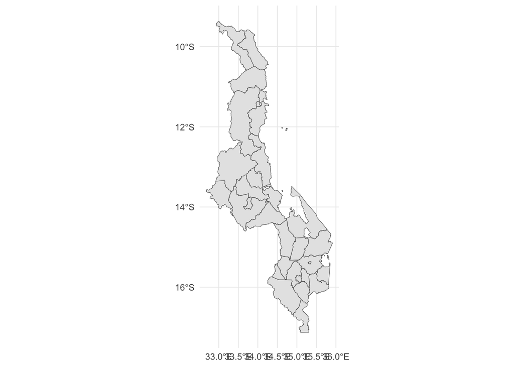

```r
area_merged <- read_sf(system.file("extdata/demo_areas.geojson", package = "naomi"))

area_merged %>%
  filter(area_level == max(area_level)) %>%
  ggplot() +
  geom_sf(aes(geometry = geometry)) +
  theme_minimal()
```

The population data is as follows, with columns:

- `area_id`: contains the ISO, area level, and area identifier.
- `source`: where did this information come from?
- `calendar_quarter`: contains the type of year (such as CY for calendar year), the year, and the quarter
- `sex`: either female or male.
- `age_group`: in the format `Ylower_upper` where e.g. for 15-49 `lower = 15` and `upper = 49`.
- `population`: the population, which might not be an integer I guess due to survey weighting.
- `area_name`: the plain text version of the area name.
- `asfr`: age-sex fertility rate.

```r
pop_agesex <- read_csv(system.file("extdata/demo_population_agesex.csv", package = "naomi"))
head(pop_agesex)
```

| area_id | source | calendar_quarter | sex | age_group | population | area_name | asfr |
| --- | --- | --- | --- | --- | --- | --- | --- |
| MWI_4_1_demo | Census 2018 | CY2008Q2 | female | Y000_004 | 16155.886 | Chitipa | NA |
| MWI_4_1_demo | Census 2018 | CY2008Q2 | female | Y005_009 | 14445.690 | Chitipa | NA |
| MWI_4_1_demo | Census 2018 | CY2008Q2 | female | Y010_014 | 12442.493 | Chitipa | NA |
| MWI_4_1_demo | Census 2018 | CY2008Q2 | female | Y015_019 | 11256.444 | Chitipa | 0.1566693 |
| MWI_4_1_demo | Census 2018 | CY2008Q2 | female | Y020_024 | 7753.054 | Chitipa | 0.2741474 |
| MWI_4_1_demo | Census 2018 | CY2008Q2 | female | Y025_029 | 5942.427 | Chitipa | 0.2487322 |

The survey data is as follows, with columns:

- `indicator`: which survey indicator is it? Takes values `"prevalence"`, `"art_coverage"`, `"viral_suppression_plhiv"` and `"recent_infected"`.
- `survey_id`: the name of the survey, containing the country, year and type.
- `survey_mid_calendar_quarter`: which calendar quarter did the survey occur during?
- `area_id`: as before.
- `area_name`: as before.
- `res_type`: unknown.
- `sex`: as before.
- `age_group`: as before.
- `n_clusters`: the number of survey clusters in this area.
- `n_observations`: the number of individuals surveyed.
- `n_eff_kish`: the Kish effective sample size.
- `estimate`: a survey weighted estimate of the indicator.
- `std_error`: standard error of `estimate`.
- `ci_lower`: 95% lower confidence interval for `estimate`.
- `ci_upper`: 95% upper confidence interval for `estimate`.

```r
survey_hiv_indicators <- read_csv(system.file("extdata/demo_survey_hiv_indicators.csv", package = "naomi"))
head(survey_hiv_indicators)
```

| indicator | survey_id | survey_mid_calendar_quarter | area_id | area_name | res_type | sex | age_group | n_clusters | n_observations | n_eff_kish | estimate | std_error | ci_lower | ci_upper |
| --- | --- | --- | --- | --- | --- | --- | --- | --- | --- | --- | --- | --- | --- | --- |
| prevalence | DEMO2004DHS | CY2004Q4 | MWI | Malawi - Demo | all | both | Y015_049 | 512 | 5136 | 3125.6878 | 0.11830934 | 0.006909679 | 0.10542327 | 0.13253713 |
| prevalence | DEMO2004DHS | CY2004Q4 | MWI | Malawi - Demo | all | both | Y015_024 | 477 | 2116 | 1302.2686 | 0.06019422 | 0.006004861 | 0.04944701 | 0.07309769 |
| prevalence | DEMO2004DHS | CY2004Q4 | MWI | Malawi - Demo | all | both | Y025_034 | 476 | 1728 | 1037.1057 | 0.15525312 | 0.012247958 | 0.13273157 | 0.18079942 |
| prevalence | DEMO2004DHS | CY2004Q4 | MWI | Malawi - Demo | all | both | Y035_049 | 432 | 1292 | 789.1170 | 0.16024140 | 0.013218554 | 0.13599446 | 0.18787139 |
| prevalence | DEMO2004DHS | CY2004Q4 | MWI | Malawi - Demo | all | both | Y015_019 | 392 | 1000 | 655.6498 | 0.02103571 | 0.004860171 | 0.01334944 | 0.03299953 |
| prevalence | DEMO2004DHS | CY2004Q4 | MWI | Malawi - Demo | all | both | Y020_024 | 419 | 1116 | 652.6522 | 0.09451939 | 0.010178819 | 0.07636711 | 0.11644246 |

The ART programmatic data is as follows, with columns:

- `area_id`: as before.
- `area_name`: as before.
- `sex`: as before.
- `age_group`: as before.
- `year`: the year.
- `calendar_quarter`: the calendar quarter.
- `art_current`: unknown.
- `art_new`: unknown.
- `vl_tested_12mos`: viral load tested past 12 months.
- `vl_suppressed_12mos`: viral load suppressed past 12 months.

```r
art_number <- read_csv(system.file("extdata/demo_art_number.csv", package = "naomi"))
head(art_number)
```

| area_id | area_name | sex | age_group | year | calendar_quarter | art_current | art_new | vl_tested_12mos | vl_suppressed_12mos |
| --- | --- | --- | --- | --- | --- | --- | --- | --- | --- |
| MWI_4_1_demo | Chitipa | both | Y000_014 | 2011 | CY2011Q4 | 127 | 9 | NA | NA |
| MWI_4_1_demo | Chitipa | both | Y015_999 | 2011 | CY2011Q4 | 1989 | 144 | NA | NA |
| MWI_4_1_demo | Chitipa | both | Y000_014 | 2012 | CY2012Q4 | 160 | 8 | NA | NA |
| MWI_4_1_demo | Chitipa | both | Y015_999 | 2012 | CY2012Q4 | 2503 | 118 | NA | NA |
| MWI_4_1_demo | Chitipa | both | Y000_014 | 2013 | CY2013Q4 | 194 | 9 | NA | NA |
| MWI_4_1_demo | Chitipa | both | Y015_999 | 2013 | CY2013Q4 | 3047 | 148 | NA | NA |

```r
anc_testing <- read_csv(system.file("extdata/demo_anc_testing.csv", package = "naomi"))
head(anc_testing)
```

| area_id | area_name | age_group | year | anc_clients | anc_known_pos | anc_already_art | anc_tested | anc_tested_pos | anc_known_neg | births_facility |
| --- | --- | --- | --- | --- | --- | --- | --- | --- | --- | --- |
| MWI_4_1_demo | Chitipa | Y015_049 | 2011 | 4330 | 24 | 0 | 2105 | 50 | 217 | 3279 |
| MWI_4_1_demo | Chitipa | Y015_049 | 2012 | 8571 | 34 | 17 | 3125 | 41 | 290 | 6059 |
| MWI_4_1_demo | Chitipa | Y015_049 | 2013 | 8300 | 57 | 45 | 5188 | 132 | 131 | 6669 |
| MWI_4_1_demo | Chitipa | Y015_049 | 2014 | 7697 | 59 | 56 | 6032 | 88 | 119 | 6187 |
| MWI_4_1_demo | Chitipa | Y015_049 | 2015 | 7517 | 263 | 79 | 6055 | 85 | 127 | 6132 |
| MWI_4_1_demo | Chitipa | Y015_049 | 2016 | 7460 | 109 | 101 | 6782 | 110 | 142 | 6163 |

```r
pjnz <- system.file("extdata/demo_mwi2019.PJNZ", package = "naomi")
spec <- extract_pjnz_naomi(pjnz)
head(spec)
```

| iso3 | spectrum_country | spectrum_region_code | spectrum_region_name | year | quarter | age | sex | totpop | hivpop | artpop | infections | asfr | pregprev | pregartcov | artpop_dec31 | unaware |
| --- | --- | --- | --- | --- | --- | --- | --- | --- | --- | --- | --- | --- | --- | --- | --- | --- |
| MWI | Malawi | 0 | Malawi | 1970 | 2 | 0 | male | 90168.08 | 0 | 0 | 0 | NA | NA | NA | 0 | 0 |
| MWI | Malawi | 0 | Malawi | 1970 | 2 | 1 | male | 83994.90 | 0 | 0 | 0 | NA | NA | NA | 0 | 0 |
| MWI | Malawi | 0 | Malawi | 1970 | 2 | 2 | male | 78515.90 | 0 | 0 | 0 | NA | NA | NA | 0 | 0 |
| MWI | Malawi | 0 | Malawi | 1970 | 2 | 3 | male | 73677.27 | 0 | 0 | 0 | NA | NA | NA | 0 | 0 |
| MWI | Malawi | 0 | Malawi | 1970 | 2 | 4 | male | 69421.60 | 0 | 0 | 0 | NA | NA | NA | 0 | 0 |
| MWI | Malawi | 0 | Malawi | 1970 | 2 | 5 | male | 65695.09 | 0 | 0 | 0 | NA | NA | NA | 0 | 0 |

## Choose model areas and time points

- `scope`: A collection of `area_id`s defining the set of areas to be modelled. Usually this is simply national level, so the level 0 `area_id`.
- `level`: Area level at which to fit the model.
- `quarter_id_t1`: The first time point for the model – approximately the midpoint of the household survey data used.
- `quarter_id_t2`: The second time point for the model – the current time for which estimates are needed.
- `quarter_id_t3`: The third time point for the model – the future projection for HIV estimates.

```r
scope <- "MWI"
level <- 4
calendar_quarter_t1 <- "CY2016Q1"
calendar_quarter_t2 <- "CY2018Q3"
calendar_quarter_t3 <- "CY2019Q4"
```

```r
prev_survey_ids  <- c("DEMO2016PHIA", "DEMO2015DHS")
artcov_survey_ids  <- "DEMO2016PHIA"
vls_survey_ids <- NULL
recent_survey_ids <- "DEMO2016PHIA"

artnum_calendar_quarter_t1 <- "CY2016Q1"
artnum_calendar_quarter_t2 <- "CY2018Q3"

anc_clients_year2 <- 2018
anc_clients_year2_num_months <- 9

anc_prevalence_year1 <- 2016
anc_prevalence_year2 <- 2018

anc_art_coverage_year1 <- 2016
anc_art_coverage_year2 <- 2018
```

## Review input data

This section is missing from the vignette!

## Prepare model inputs

Setup the model:

```r
naomi_mf <- naomi_model_frame(
  area_merged,
  pop_agesex,
  spec,
  scope = scope,
  level = level,
  calendar_quarter_t1,
  calendar_quarter_t2,
  calendar_quarter_t3
)
```

Prepare data inputs

```r
naomi_data <- select_naomi_data(
  naomi_mf,
  survey_hiv_indicators,
  anc_testing,
  art_number,
  prev_survey_ids,
  artcov_survey_ids,
  recent_survey_ids,
  vls_survey_ids,
  artnum_calendar_quarter_t1,
  artnum_calendar_quarter_t2,
  anc_prevalence_year1,
  anc_prevalence_year2,
  anc_art_coverage_year1,
  anc_art_coverage_year2
)
```

## Fit the TMB model

```r
tmb_inputs <- prepare_tmb_inputs(naomi_data)
fit <- fit_tmb(tmb_inputs)
```

[output not shown]

[output cut: 33 more lines]

```
## converged: relative convergence (4)
```

Calculate model outputs:

```r
outputs <- output_package(fit, naomi_data) #' Note that in the vignette they have naomi_mf here, is this a mistake?
```

The output package consists of a data frame of indicators and metadata defining the labels for each indicator:

```r
names(outputs)
```

```
## [1] "indicators"     "art_attendance" "meta_area"      "meta_age_group" "meta_period"    "meta_indicator"
## [7] "fit"            "inputs_outputs"
```

If uncertainty has not been calcualted yet, the output object retures values for the mode, but not the mean or lower and upper 95% uncertainty ranges:

```r
outputs$indicators %>%
  dplyr::filter(
    indicator == "prevalence",  #' HIV prevalence
    age_group == "Y015_049"   #' Age group 15-49
  ) %>%
  head()
```

| area_id | sex | age_group | calendar_quarter | indicator | mean | se | median | mode | lower | upper |
| --- | --- | --- | --- | --- | --- | --- | --- | --- | --- | --- |
| MWI | both | Y015_049 | CY2016Q1 | prevalence | NA | NA | NA | 0.08901762 | NA | NA |
| MWI | female | Y015_049 | CY2016Q1 | prevalence | NA | NA | NA | 0.11086322 | NA | NA |
| MWI | male | Y015_049 | CY2016Q1 | prevalence | NA | NA | NA | 0.06683865 | NA | NA |
| MWI_1_1_demo | both | Y015_049 | CY2016Q1 | prevalence | NA | NA | NA | 0.06772894 | NA | NA |
| MWI_1_1_demo | female | Y015_049 | CY2016Q1 | prevalence | NA | NA | NA | 0.08298675 | NA | NA |
| MWI_1_1_demo | male | Y015_049 | CY2016Q1 | prevalence | NA | NA | NA | 0.05223015 | NA | NA |

The function `add_output_labels()` returns the indicators table with labels added as additional columns:

```r
add_output_labels(outputs) %>%
  dplyr::filter(
    indicator == "prevalence",  # HIV prevalence
    age_group == "Y015_049"   # Age group 15-49
  ) %>%
  head()
```

| area_level | area_level_label | area_id | area_name | sex | age_group | age_group_label | calendar_quarter | quarter_label | indicator | indicator_label | mean | se | median | mode | lower | upper |
| --- | --- | --- | --- | --- | --- | --- | --- | --- | --- | --- | --- | --- | --- | --- | --- | --- |
| 0 | Country | MWI | Malawi - Demo | both | Y015_049 | 15-49 | CY2016Q1 | March 2016 | prevalence | HIV prevalence | NA | NA | NA | 0.08901762 | NA | NA |
| 0 | Country | MWI | Malawi - Demo | female | Y015_049 | 15-49 | CY2016Q1 | March 2016 | prevalence | HIV prevalence | NA | NA | NA | 0.11086322 | NA | NA |
| 0 | Country | MWI | Malawi - Demo | male | Y015_049 | 15-49 | CY2016Q1 | March 2016 | prevalence | HIV prevalence | NA | NA | NA | 0.06683865 | NA | NA |
| 0 | Country | MWI | Malawi - Demo | both | Y015_049 | 15-49 | CY2018Q3 | September 2018 | prevalence | HIV prevalence | NA | NA | NA | 0.09079756 | NA | NA |
| 0 | Country | MWI | Malawi - Demo | female | Y015_049 | 15-49 | CY2018Q3 | September 2018 | prevalence | HIV prevalence | NA | NA | NA | 0.10785266 | NA | NA |
| 0 | Country | MWI | Malawi - Demo | male | Y015_049 | 15-49 | CY2018Q3 | September 2018 | prevalence | HIV prevalence | NA | NA | NA | 0.07352974 | NA | NA |

```r
system.time(fit <- sample_tmb(fit))
```

```
##    user  system elapsed
##   7.550   1.822  10.186
```

Regenerate outputs with uncertainty ranges:

```r
system.time(outputs <- output_package(fit, naomi_data))
```

```
##    user  system elapsed
##  82.431   1.401  83.861
```

```r
outputs_calib <- calibrate_outputs(
  outputs,
  naomi_mf,
  spectrum_plhiv_calibration_level = "national",
  spectrum_plhiv_calibration_strat = "sex_age_coarse",
  spectrum_artnum_calibration_level = "national",
  spectrum_artnum_calibration_strat = "sex_age_coarse",
  spectrum_aware_calibration_level = "national",
  spectrum_aware_calibration_strat = "sex_age_coarse",
  spectrum_infections_calibration_level = "national",
  spectrum_infections_calibration_strat = "sex_age_coarse"
)

outputs$indicators %>%
  dplyr::filter(
    indicator == "prevalence",  # HIV prevalence
    age_group == "Y015_049"   # Age group 15-49
  ) %>%
  head()
```

| area_id | sex | age_group | calendar_quarter | indicator | mean | se | median | mode | lower | upper |
| --- | --- | --- | --- | --- | --- | --- | --- | --- | --- | --- |
| MWI | both | Y015_049 | CY2016Q1 | prevalence | 0.08943134 | 0.001359709 | 0.08941854 | 0.08901762 | 0.08681840 | 0.09220607 |
| MWI | female | Y015_049 | CY2016Q1 | prevalence | 0.11126151 | 0.001978116 | 0.11128144 | 0.11086322 | 0.10728246 | 0.11509742 |
| MWI | male | Y015_049 | CY2016Q1 | prevalence | 0.06726804 | 0.002056773 | 0.06717430 | 0.06683865 | 0.06363982 | 0.07142676 |
| MWI_1_1_demo | both | Y015_049 | CY2016Q1 | prevalence | 0.06805153 | 0.001853139 | 0.06798148 | 0.06772894 | 0.06451690 | 0.07172524 |
| MWI_1_1_demo | female | Y015_049 | CY2016Q1 | prevalence | 0.08334924 | 0.002715118 | 0.08329746 | 0.08298675 | 0.07795991 | 0.08855727 |
| MWI_1_1_demo | male | Y015_049 | CY2016Q1 | prevalence | 0.05251220 | 0.002619317 | 0.05242643 | 0.05223015 | 0.04769354 | 0.05803933 |

## Plot model outputs

```r
indicators <- add_output_labels(outputs) %>%
  left_join(outputs$meta_area %>% select(area_level, area_id, center_x, center_y)) %>%
  sf::st_as_sf()
```

15-49 prevalence by district (which is `area_level` 4):

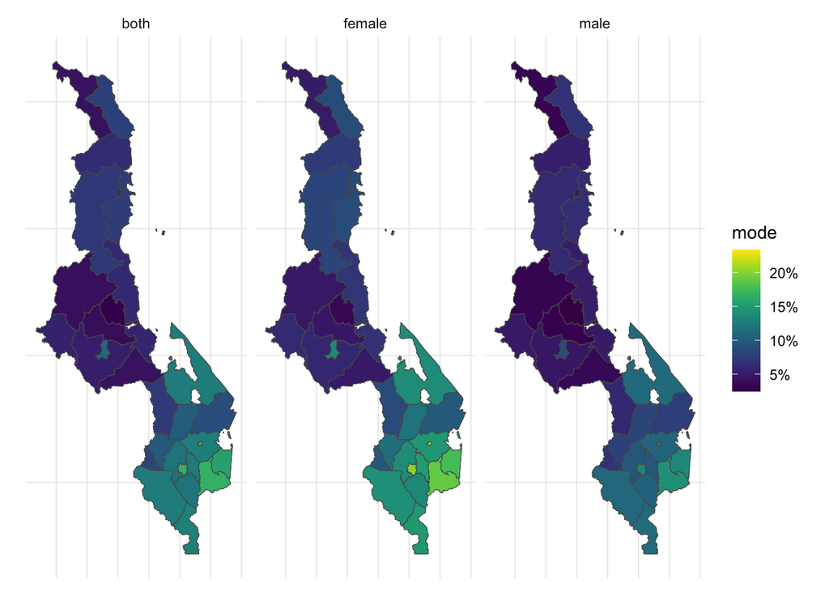

```r
indicators %>%
  filter(age_group == "Y015_049",
         indicator == "prevalence",
         area_level == 4) %>%
  ggplot(aes(fill = mode)) +
  geom_sf() +
  viridis::scale_fill_viridis(labels = scales::percent_format()) +
  th_map() +
  facet_wrap(~sex)
```

15-49 prevalence by zone (which is `area_level` 2):

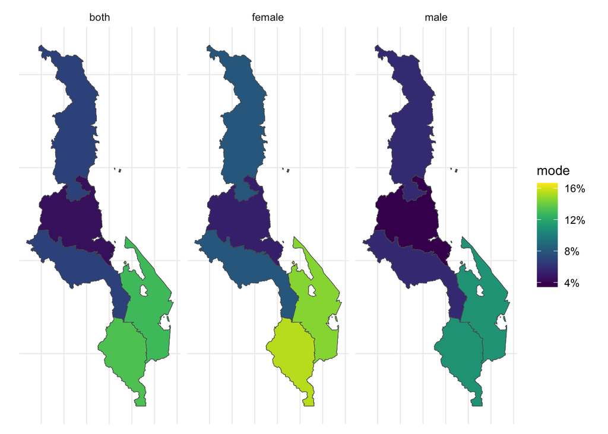

```r
indicators %>%
  filter(age_group == "Y015_049",
         indicator == "prevalence",
         area_level == 2) %>%
  ggplot(aes(fill = mode)) +
  geom_sf() +
  viridis::scale_fill_viridis(labels = scales::percent_format()) +
  th_map() +
  facet_wrap(~sex)
```

Age-specific prevalence at a national-level:

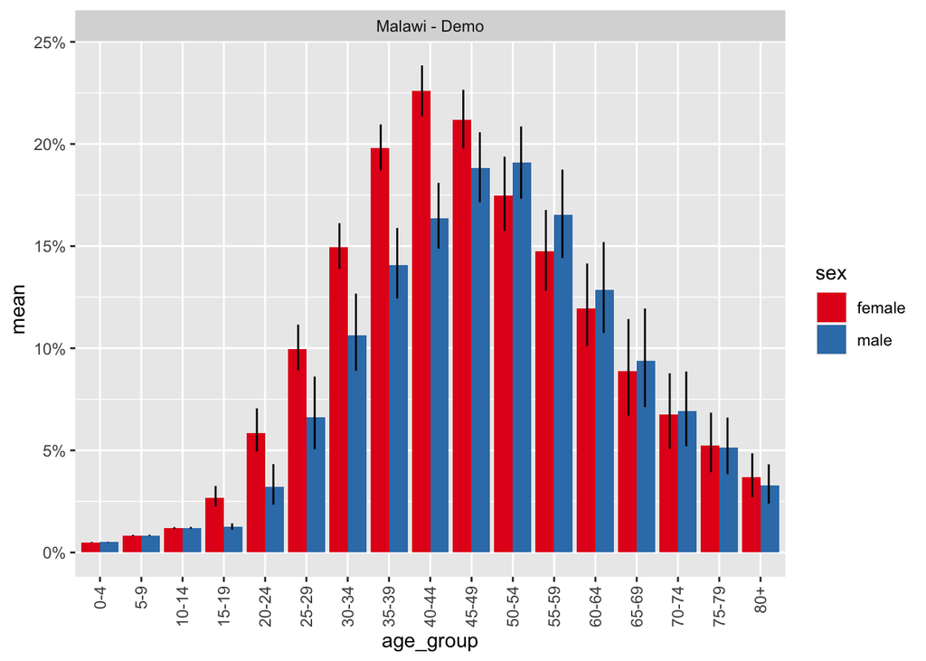

```r
indicators %>%
  dplyr::filter(area_level == 0,
         sex != "both",
         age_group %in% get_five_year_age_groups(),
         calendar_quarter == "CY2018Q3",
         indicator == "prevalence") %>%
  left_join(get_age_groups()) %>%
  mutate(age_group = fct_reorder(age_group_label, age_group_sort_order)) %>%
  ggplot(aes(age_group, mean, ymin = lower, ymax = upper, fill = sex)) +
  geom_col(position = "dodge") +
  geom_linerange(position = position_dodge(0.8)) +
  scale_fill_brewer(palette = "Set1") +
  scale_y_continuous(labels = scales::percent_format(1)) +
  facet_wrap(~area_name) +
  theme(axis.text.x = element_text(angle = 90, hjust = 1.0, vjust = 0.5))
```

ART coverage by age-sex-region:

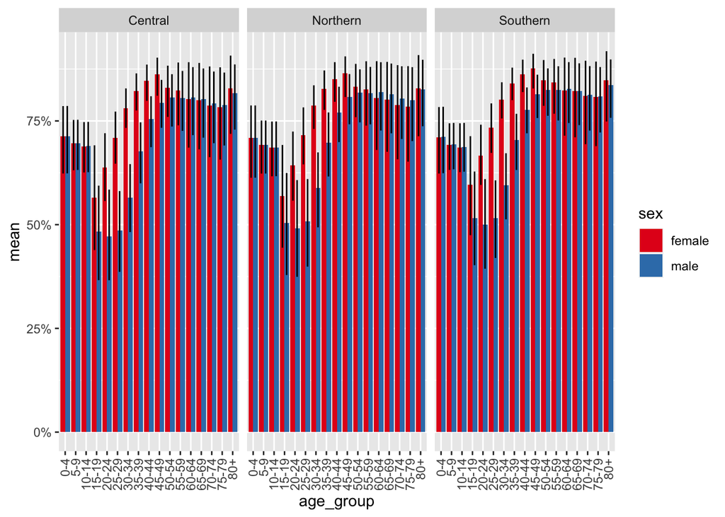

```r
indicators %>%
  filter(area_level == 1,
         sex != "both",
         age_group %in% get_five_year_age_groups(),
         indicator == "art_coverage",
         calendar_quarter == "CY2018Q3") %>%
  left_join(get_age_groups()) %>%
  mutate(age_group = fct_reorder(age_group_label, age_group_sort_order)) %>%
  ggplot(aes(age_group, mean, ymin = lower, ymax = upper, fill = sex)) +
  geom_col(position = "dodge") +
  geom_linerange(position = position_dodge(0.8)) +
  scale_fill_brewer(palette = "Set1") +
  scale_y_continuous(labels = scales::percent_format(1)) +
  facet_wrap(~area_name) +
  theme(axis.text.x = element_text(angle = 90, hjust = 1.0, vjust = 0.5))
```

Bubble plot of prevalence and PLHIV:

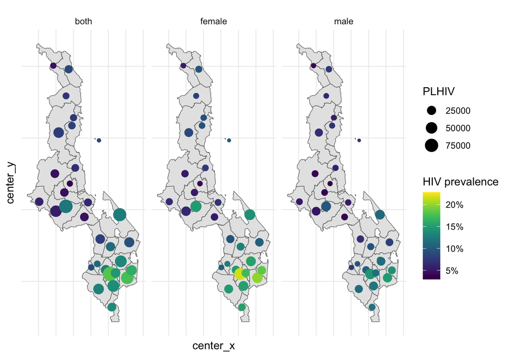

```r
indicators %>%
  filter(age_group == "Y015_064",
         area_level == 4,
         indicator %in% c("prevalence", "plhiv"),
         calendar_quarter == "CY2018Q3") %>%
  select(sex, center_x, center_y, indicator_label, mean) %>%
  spread(indicator_label, mean) %>%
  ggplot() +
  geom_sf() +
  geom_point(aes(center_x, center_y, colour = `HIV prevalence`, size = PLHIV)) +
  viridis::scale_color_viridis(labels = scales::percent_format()) +
  th_map() +
  facet_wrap(~sex)
```